# Analisis de Ventas

[figure not shown]

*Super Store India es una empresa ubicada en Tamil Nadu, India. Esta empresa se dedica a la venta de productos vía una aplicación de entrega de comestibles. El conjunto de datos contiene información geográfica de ventas y de ganancias de Super Store India.*

> Nuestra tarea es analizar los datos de ventas e identificar áreas débiles y oportunidades para que Super Store India impulse el crecimiento del negocio.

### Definición de variables

Se cuenta con una tabla de datos de 11 variables

Definición de variables

| **N°** | **Variable** | **Tipo de variable** |
| --- | --- | --- |
| *1* | *Orden ID* | *Cualitativa Nominal* |
| *2* | *Nombre del Cliente* | *Cualitativa Nominal* |
| *3* | *Categoria del Producto* | *Cualitativa Nominal* |
| *4* | *Sub Categoría del Producto* | *Cualitativa Nominal* |
| *5* | *Ciudad* | *Cualitativa Nominal* |
| *6* | *Fecha de Orden* | *Cuantitativa Discreta* |
| *7* | *Region* | *Cualitativa Nominal* |
| *8* | *Venta* | *Cuantitativa Continua* |
| *9* | *Descuento* | *Cuantitativa Continua* |
| *10* | *Ganancia* | *Cuantitativa Continua* |
| *11* | *Estado* | *Cualitativa Nominal* |

## Caso de Análisis

**Primera Parte**

**Preguntas comerciales**

## Análisis exploratorio de datos

### 1. ¿Qué categoría es la más vendida y la más rentable?

Agruparemos las ventas, las ganancias y también la cantidad por categoría para poder saber cual es la categoría mas rentable

## Ventas Por Región

**Analisis de Ventas**

```r
totalVentas<-aggregate(x=indiaStore$Venta,by=list(indiaStore$Region),FUN=sum)
datatable(totalVentas[order(totalVentas$x,decreasing = TRUE),])
```

|  | Group.1 | x |
| --- | --- | --- |
| 5 | West | 4798743 |
| 2 | East | 4248368 |
| 1 | Central | 3468156 |
| 4 | South | 2440461 |
| 3 | North | 1254 |

Como podemos observar la región en donde se realizaron mayores ventas fue “West” y donde se realizaron menores ventas fue “North”

```r
ventasRegion <- c(4798743, 4248368 , 3468156, 2440461, 1254)
etiquetas1 <- c("West", "East", "Central", "South", "North")
pct1 <- round(ventasRegion/sum(ventasRegion)*100)
etiquetas1 <- paste(ventasRegion, pct1)
etiquetas1 <- paste(ventasRegion,"%",sep="")
```

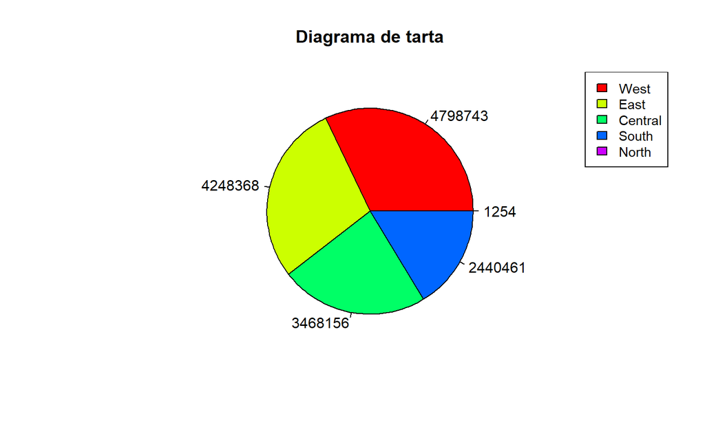

```r
pie(ventasRegion,labels = ventasRegion,
    col=rainbow(length(etiquetas1)),
    main="Diagrama de tarta")

legend("topright", c("West", "East", "Central", "South", "North"), cex = 0.9,
       fill = rainbow(length(ventasRegion)))
```

## Diagrama de Ventas y ganancias por Categoría de producto

Para poder entender mejor cuales son las categorias de productos donde se tienen mayores ganancias recurriremos a un análisis a través de diagramas de barras

```r
categoria <- indiaStore$Categoría
ventas <- indiaStore$Venta
ventas_categoria <- data.frame(categoria,ventas)
diagramaCat_Venta <-  aggregate(x=ventas_categoria$ventas, by=list(ventas_categoria$categoria),FUN = sum)
diagramaCat_Venta
```

```
##             Group.1       x
## 1            Bakery 2112281
## 2         Beverages 2085313
## 3 Eggs, Meat & Fish 2267401
## 4       Food Grains 2115272
## 5  Fruits & Veggies 2100727
## 6      Oil & Masala 2038442
## 7            Snacks 2237546
```

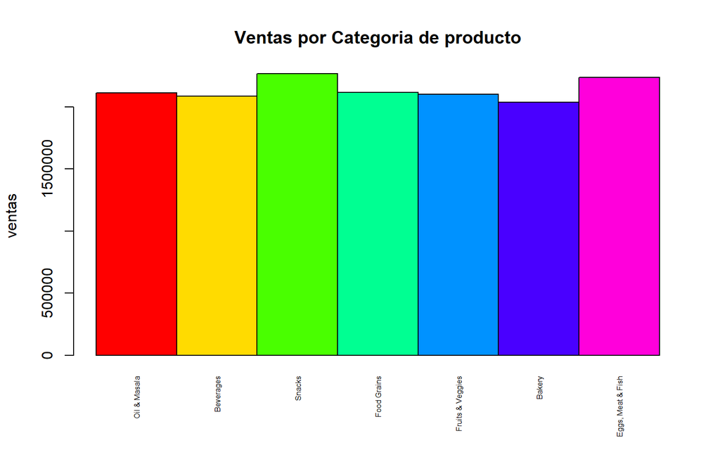

```r
barplot(diagramaCat_Venta$x, main ="Ventas por Categoria de producto", names.arg=c("Oil & Masala","Beverages","Snacks","Food Grains","Fruits & Veggies","Bakery","Eggs, Meat & Fish"), col=rainbow(7),space =0,las=3, xlab="",  ylab="ventas",cex.names=0.5,cey.names=0.5)
```

Por el diagrama podemos saber que las categorías de productos “Snacks” y “Eggs, Meat & Fish” son lo que tienen mayores ventas. Asimismo, no debemos descartar que no se tiene una categoría que tenga ventas no considerables

Por otro lado, vamos a analizar las ganancias por Categoría de producto

```r
profit <- indiaStore$Ganacia

profit_categoria <- data.frame(categoria,profit)

diagrama2 <-  aggregate(x=profit, by=list(categoria),FUN = sum)
```

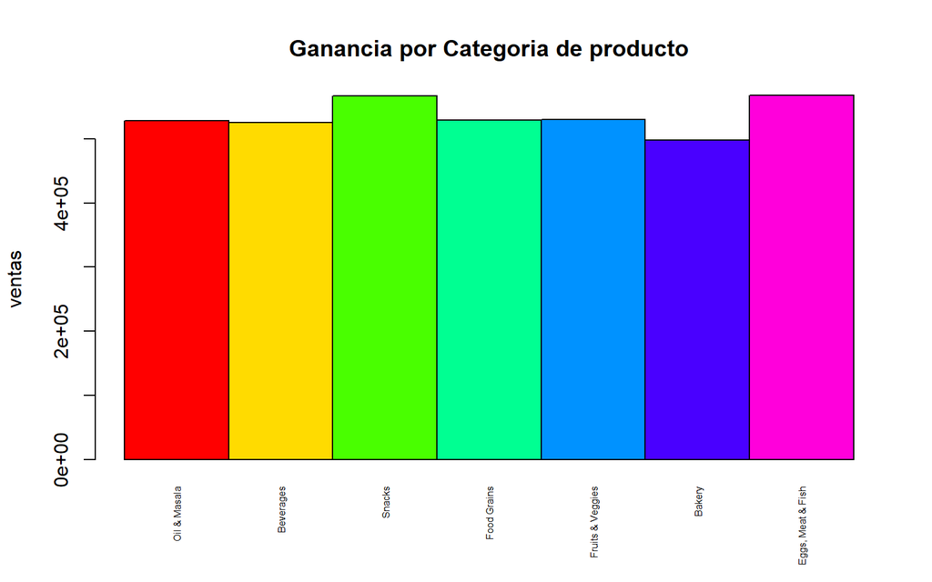

```r
barplot(diagrama2$x, main ="Ganancia por Categoria de producto", names.arg=c("Oil & Masala","Beverages","Snacks","Food Grains","Fruits & Veggies","Bakery","Eggs, Meat & Fish"), col=rainbow(7),space =0,las=3, xlab="",  ylab="ventas",cex.names=0.5,cey.names=0.5)
```

### 2. ¿Cuáles son las subcategorías más vendidas?

```r
Subcategoriamasvendida<-aggregate(x=indiaStore$Venta,by=list(indiaStore$`Sub Categoría`), FUN=sum)
```

```r
datatable(Subcategoriamasvendida[order(Subcategoriamasvendida$x,decreasing = TRUE),])
```

|  | Group.1 | x |
| --- | --- | --- |
| 14 | Health Drinks | 1051439 |
| 22 | Soft Drinks | 1033874 |
| 7 | Cookies | 768213 |
| 3 | Breads &amp; Buns | 742586 |
| 17 | Noodles | 735435 |
| 6 | Chocolates | 733898 |
| 15 | Masalas | 697480 |
| 4 | Cakes | 685612 |
| 2 | Biscuits | 684083 |
| 23 | Spices | 672876 |

[output cut: 13 more lines]

### ¿Cuáles son las subcategorías más rentables?

```r
Subcategoriamasprofit<-aggregate(x=indiaStore$Ganacia,by=list(indiaStore$`Sub Categoría`), FUN=sum)
```

```r
datatable(Subcategoriamasprofit[order(Subcategoriamasprofit$x,decreasing = TRUE),])
```

|  | Group.1 | x |
| --- | --- | --- |
| 14 | Health Drinks | 267469.79 |
| 22 | Soft Drinks | 258135.97 |
| 17 | Noodles | 193685.81 |
| 3 | Breads &amp; Buns | 190764.98 |
| 7 | Cookies | 190643.7 |
| 6 | Chocolates | 183849.34 |
| 2 | Biscuits | 169357.62 |
| 15 | Masalas | 168999.11 |
| 9 | Edible Oil &amp; Ghee | 168593.58 |
| 4 | Cakes | 168398.46 |

[output cut: 13 more lines]

### Gráficos de barras que muestran los más vendidos y los más rentables para la subcategoría

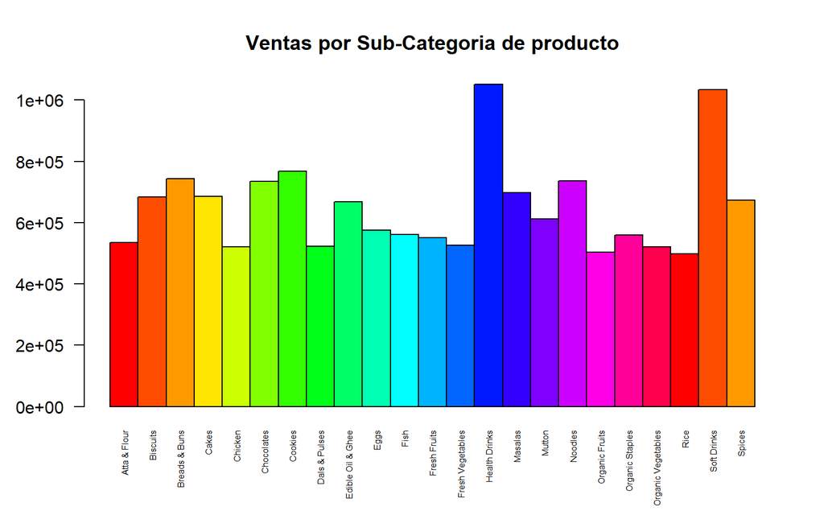

```r
barplot(diagrama$x, main ="Ventas por Sub-Categoria de producto", names.arg=c("Atta & Flour","Biscuits","Breads & Buns","Cakes","Chicken","Chocolates","Cookies","Dals & Pulses","Edible Oil & Ghee","Eggs","Fish","Fresh Fruits","Fresh Vegetables","Health Drinks","Masalas","Mutton","Noodles","Organic Fruits","Organic Staples","Organic Vegetables","Rice","Soft Drinks","Spices"), col=rainbow(20),space =0,las=2,cex.names = 0.5,cey.names=0.0001)
```

```r
subcategoria <- indiaStore$`Sub Categoría`
beneficios <- indiaStore$Ganacia

beneficios_Subcategoria <- data.frame(subcategoria,beneficios)

diagrama <-  aggregate(x=beneficios_Subcategoria$beneficios, by=list(beneficios_Subcategoria$subcategoria),FUN = sum)
```

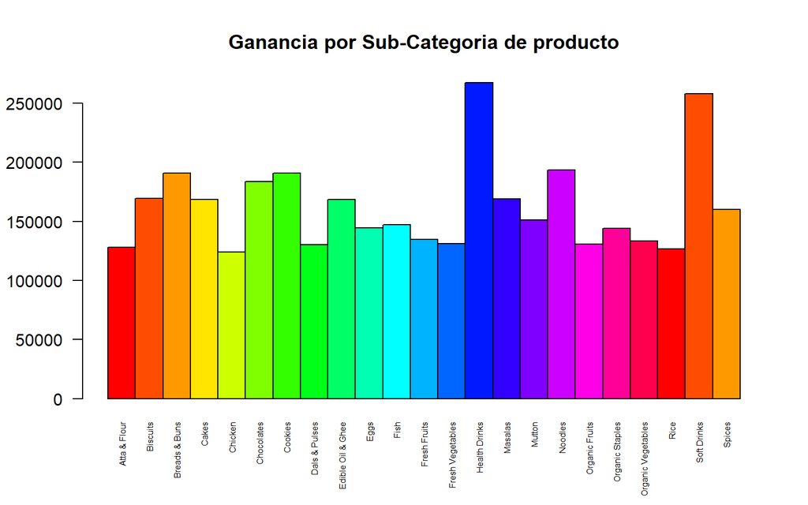

```r
barplot(diagrama$x, main ="Ganancia por Sub-Categoria de producto", names.arg=c("Atta & Flour","Biscuits","Breads & Buns","Cakes","Chicken","Chocolates","Cookies","Dals & Pulses","Edible Oil & Ghee","Eggs","Fish","Fresh Fruits","Fresh Vegetables","Health Drinks","Masalas","Mutton","Noodles","Organic Fruits","Organic Staples","Organic Vegetables","Rice","Soft Drinks","Spices"), col=rainbow(20),space =0,las=2,cex.names = 0.5,cey.names=0.0001)
```

## Analisis II

Vamos a proceder a realizar el ajuste de distribución de las variables cuantitativas. Para ello es fundamental identificar aquellas variables

| Variable | Clasificación Variable | Tipo |
| --- | --- | --- |
| Venta | Cuantitativa | Continua |
| Descuento | Cuantitativa | Continua |
| Ganancia | Cuantitativa | Continua |

### Variable Venta :

Para determinar el modelo de distribución que puede seguir este conjunto de datos obtenemos el gráfico de Cullen & Frey. Así, tenemos una primera idea de qué tipo de distribución se asemeja ás a nuestros datos.

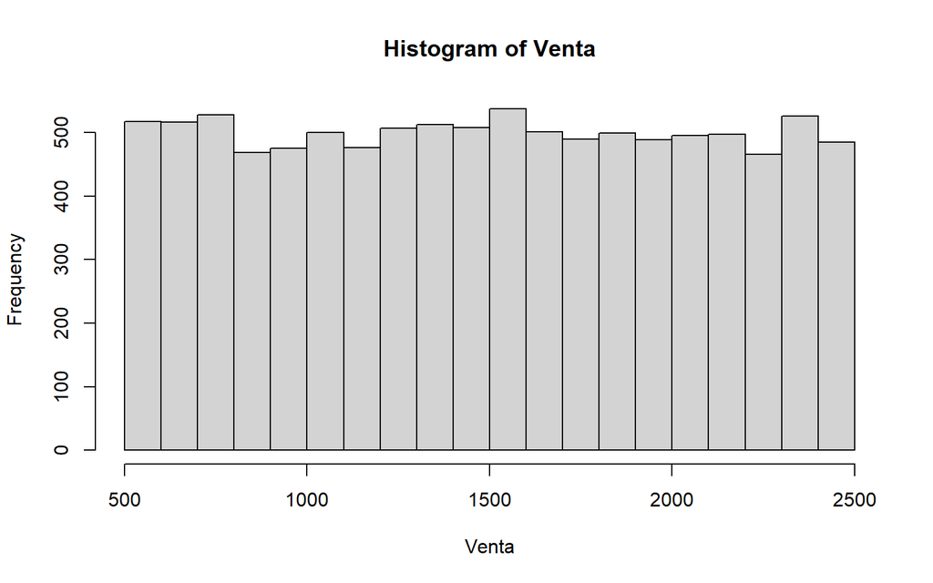

```r
Venta <- indiaStore$Venta

hist(Venta)
```

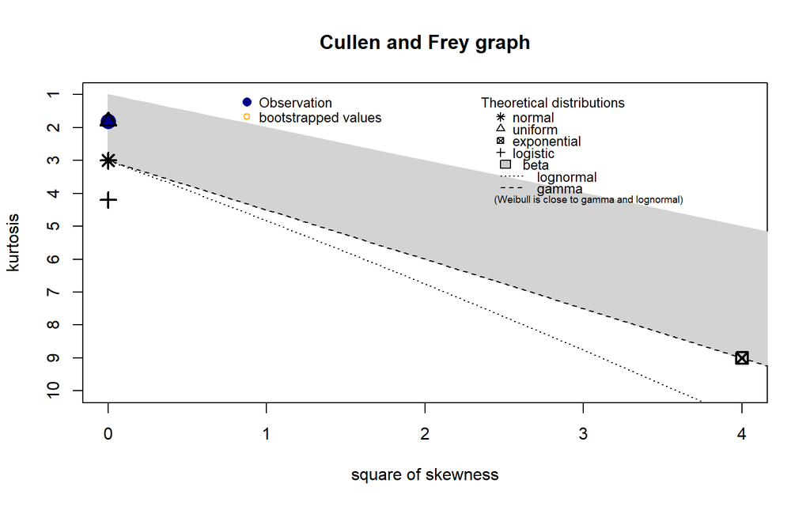

```
## summary statistics
## ------
## min:  500   max:  2500
## median:  1498
## mean:  1496.596
## estimated sd:  577.559
## estimated skewness:  0.0009265385
## estimated kurtosis:  1.811657
```

```r
#es1 <- fit.cont(Venta)

descdist(Venta, discrete = FALSE, boot=100)
```

```r
#Distribucion Uniforme
fit_u  <- fitdist(Venta, "unif")
summary(fit_u)
```

```
## Fitting of the distribution ' unif ' by maximum likelihood
## Parameters :
##     estimate Std. Error
## min      500         NA
## max     2500         NA
## Loglikelihood:  -75963.42   AIC:  151930.8   BIC:  151945.3
## Correlation matrix:
## [1] NA
```

```r
#Distribucion Normal
fit_n <- fitdist(Venta, "norm")
summary(fit_n)
```

```
## Fitting of the distribution ' norm ' by maximum likelihood
## Parameters :
##       estimate Std. Error
## mean 1496.5962   5.777125
## sd    577.5301   4.085044
## Loglikelihood:  -77730.33   AIC:  155464.7   BIC:  155479.1
## Correlation matrix:
##      mean sd
## mean    1  0
## sd      0  1
```

La los valores de la variable venta es:

```r
summary(Venta)
```

```
##    Min. 1st Qu.  Median    Mean 3rd Qu.    Max.
##     500    1000    1498    1497    1995    2500
```

Ahora procedemos a comparar las AIC de las distribuciones probables:

| Tipo de distribución | AIC obtenido |
| --- | --- |
| Uniforme | 151930.80 |
| Normal | 155464.74 |

> **Conclusión**: Teniendo en cuenta el gráfico de Cullen y Frey así como el criterio del menor AIC, podemos decir que la variable venta sigue una distribución uniforme.

En este momento, decidimos hacer una estimación de la variable cantidad para el año siguiente. Para ello, vamos a considerar una muestra de 360 días y los parámetros de la distribución uniforme, que son `valor mínimo (500)` y `valor máximo (2500)`.

Generación de la muestra:

```r
estimacion_venta<-runif(360,min = 500,max = 2500)
summary(estimacion_venta)
```

```
##    Min. 1st Qu.  Median    Mean 3rd Qu.    Max.
##   504.8   989.3  1523.1  1480.3  1939.7  2495.0
```

Cálculo de los intervalos de confianza

```r
mean(estimacion_venta)-sd(estimacion_venta)
```

```
## [1] 918.2202
```

```r
mean(estimacion_venta)+sd(estimacion_venta)
```

```
## [1] 2042.389
```

### Variable Ganancia :

Para determinar el modelo de distribución que puede seguir este conjunto de datos obtenemos el gráfico de Cullen & Frey. Así, tenemos una primera idea de qué tipo de distribución se asemejará a nuestros datos.

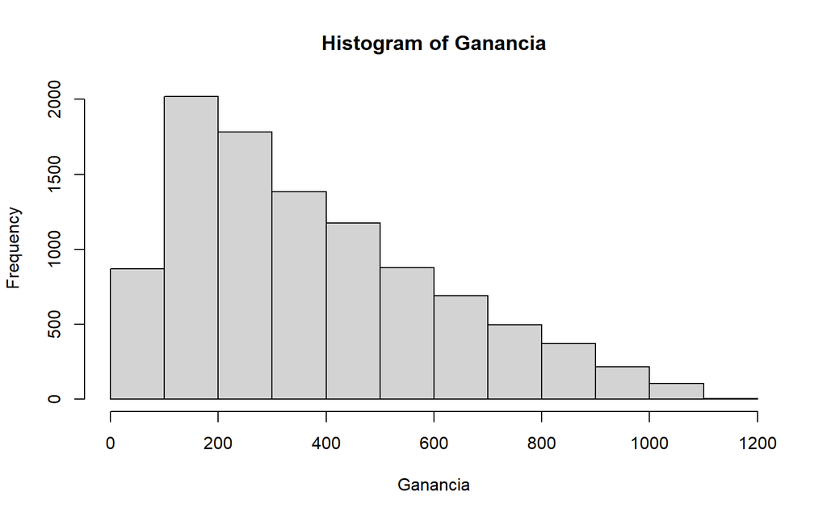

```r
Ganancia <- indiaStore$Ganacia

hist(Ganancia)
```

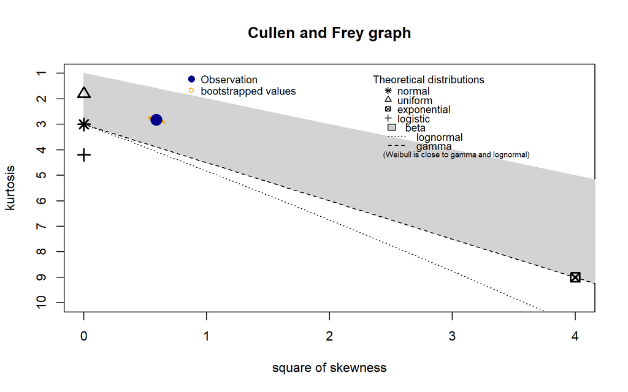

```
## summary statistics
## ------
## min:  25.25   max:  1120.95
## median:  320.78
## mean:  374.9371
## estimated sd:  239.9329
## estimated skewness:  0.7673969
## estimated kurtosis:  2.818633
```

```r
##res1 <- fit.cont(Venta)
descdist(Ganancia, discrete = FALSE, boot=100)
```

```r
#Distribucion Uniforme
fit_ln  <- fitdist(Ganancia, "lnorm")
summary(fit_ln)
```

```
## Fitting of the distribution ' lnorm ' by maximum likelihood
## Parameters :
##          estimate  Std. Error
## meanlog 5.6898329 0.007388809
## sdlog   0.7386592 0.005224634
## Loglikelihood:  -68017.69   AIC:  136039.4   BIC:  136053.8
## Correlation matrix:
##         meanlog sdlog
## meanlog       1     0
## sdlog         0     1
```

```r
#Distribucion Normal
fit_n <- fitdist(Ganancia, "norm")
summary(fit_n)
```

```
## Fitting of the distribution ' norm ' by maximum likelihood
## Parameters :
##      estimate Std. Error
## mean 374.9371   2.399896
## sd   239.9209   1.697000
## Loglikelihood:  -68951.08   AIC:  137906.2   BIC:  137920.6
## Correlation matrix:
##      mean sd
## mean    1  0
## sd      0  1
```

```r
#Distribución Weighbull
fit_w <- fitdist(Ganancia, "weibull")
summary(fit_w)
```

```
## Fitting of the distribution ' weibull ' by maximum likelihood
## Parameters :
##         estimate Std. Error
## shape   1.622372 0.01270798
## scale 419.901656 2.73267252
## Loglikelihood:  -67702.18   AIC:  135408.4   BIC:  135422.8
## Correlation matrix:
##           shape     scale
## shape 1.0000000 0.3204357
## scale 0.3204357 1.0000000
```

La los valores de la variable Ganancia son:

```r
summary(Ganancia)
```

```
##    Min. 1st Qu.  Median    Mean 3rd Qu.    Max.
##   25.25  180.02  320.78  374.94  525.63 1120.95
```

```r
sd(Ganancia)
```

```
## [1] 239.9329
```

Ahora procedemos a comprar las AIC de las distribuciones probables:

| Tipo de distribución | AIC obtenido |
| --- | --- |
| Normal | 137906.2 |
| LogNormal | 136039.4 |
| Weibull | 135408.4 |

> **Conclusión**: Teniendo en cuenta el gráfico de Cullen y Frey así como el criterio del menor AIC, podemos decir que la variable Ganancia sigue una distribución weibull.

Generación de la muestra:

```r
estimacion_Ganancia <- rweibull(360,0.3204357,scale =1)
summary(estimacion_Ganancia)
```

```
##     Min.  1st Qu.   Median     Mean  3rd Qu.     Max.
##   0.0000   0.0224   0.3159   6.8047   2.9344 356.2467
```

Cálculo de los intervalos de confianza

```r
mean(estimacion_Ganancia)-sd(estimacion_Ganancia)
```

```
## [1] -19.88424
```

```r
mean(estimacion_Ganancia)+sd(estimacion_Ganancia)
```

```
## [1] 33.49373
```

### Correlación

```r
indiaStoreCo <- indiaStore

indiaStore
```

```
## # A tibble: 9,994 × 11
##    `Orden ID` `Nombre del cliente` Categoría        `Sub Categoría`  Ciudad
##    <chr>      <chr>                <chr>            <chr>            <chr>
##  1 OD1        Harish               Oil & Masala     Masalas          Vellore
##  2 OD2        Sudha                Beverages        Health Drinks    Krishnagiri
##  3 OD3        Hussain              Food Grains      Atta & Flour     Perambalur
##  4 OD4        Jackson              Fruits & Veggies Fresh Vegetables Dharmapuri
##  5 OD5        Ridhesh              Food Grains      Organic Staples  Ooty
##  6 OD6        Adavan               Food Grains      Organic Staples  Dharmapuri
##  7 OD7        Jonas                Fruits & Veggies Fresh Vegetables Trichy
##  8 OD8        Hafiz                Fruits & Veggies Fresh Fruits     Ramanadhap…
##  9 OD9        Hafiz                Bakery           Biscuits         Tirunelveli
## 10 OD10       Krithika             Bakery           Cakes            Chennai
## # … with 9,984 more rows, and 6 more variables: `Fecha de Orden` <dttm>,
## #   Region <chr>, Venta <dbl>, Descuento <dbl>, Ganacia <dbl>, Estado <chr>
```

```r
indiaStoreCo <- select(indiaStore, -"Orden ID",-"Nombre del cliente",-"Categoría",-"Sub Categoría",-"Ciudad",-"Fecha de Orden",-"Region",-"Estado")


indiaStoreCo
```

```
## # A tibble: 9,994 × 3
##    Venta Descuento Ganacia
##    <dbl>     <dbl>   <dbl>
##  1  1254      0.12   401.
##  2   749      0.18   150.
##  3  2360      0.21   165.
##  4   896      0.25    89.6
##  5  2355      0.26   918.
##  6  2305      0.26   323.
##  7   826      0.33   347.
##  8  1847      0.32   148.
##  9   791      0.23   182.
## 10  1795      0.27   485.
## # … with 9,984 more rows
```

```r
M<-cor(indiaStoreCo)
head(round(M,2))
```

```
##           Venta Descuento Ganacia
## Venta      1.00     -0.01    0.61
## Descuento -0.01      1.00    0.00
## Ganacia    0.61      0.00    1.00
```

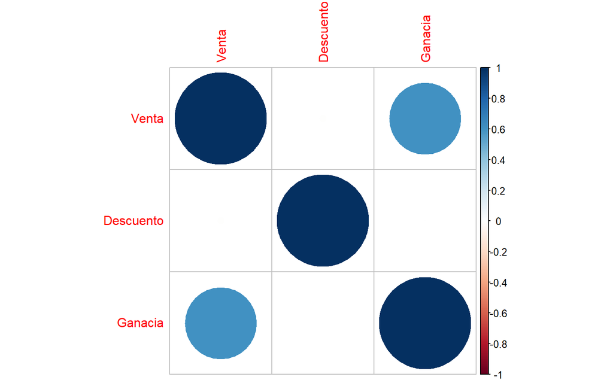

```r
library(corrplot)
corrplot(M, method="circle")
```

```r
cor(indiaStoreCo$Venta,indiaStoreCo$Descuento)
```

```
## [1] -0.005512488
```

```r
cor(indiaStoreCo$Descuento,indiaStoreCo$Ganacia)
```

```
## [1] 1.747623e-05
```

#Correlación menor a cero: Si la correlación es menor a cero, significa que es negativa, es decir, que las variables se relacionan inversamente. Cuando el valor de alguna variable es alto, el valor de la otra variable es bajo. Mientras más próximo se encuentre a -1, más clara será la covariación extrema.

# Regresiones lineales

```r
india <- indiaStore
#plot(india$Ganacia,india$Venta)
```

```r
modelo <- lm(india$Venta ~ india$Ganacia, data=india)
summary(modelo)
```

```
##
## Call:
## lm(formula = india$Venta ~ india$Ganacia, data = india)
##
## Residuals:
##     Min      1Q  Median      3Q     Max
## -778.11 -366.57  -77.86  306.56 1360.19
##
## Coefficients:
##                Estimate Std. Error t value Pr(>|t|)
## (Intercept)   950.24669    8.53214  111.37   <2e-16 ***
## india$Ganacia   1.45718    0.01917   76.02   <2e-16 ***
## ---
## Signif. codes:  0 '***' 0.001 '**' 0.01 '*' 0.05 '.' 0.1 ' ' 1
##
## Residual standard error: 459.7 on 9992 degrees of freedom
## Multiple R-squared:  0.3664, Adjusted R-squared:  0.3664
## F-statistic:  5779 on 1 and 9992 DF,  p-value: < 2.2e-16
```

Al analizar este análisis los parámetros de la ecuación de la recta de mínimos cuadrados que relaciona las ventas con la ganancia, se obtiene la recta

Y= 1.45718*X +950.24669

Que la recta se ajuste a los datos no significa que el modelo sea correcto, depende del uso que queramos darle.

Si sólo pretendemos hallar la relación entre dos variables, con calcular la recta de mínimos cuadrados es suficiente.

Si queremos verificar que tena una buena relación lineal, con el fin de inferir/ predecir con la recta de regresión debemos comprobar que se verefican unas reglas ya establecidas y acepadas que aseguran que nuestro modelo es bueno, para su verificación realizaremos los seiguientes análisis.

### Análisis de correlación

Correlación: Mide el grado de relación lineal, calculamos la matriz de coeficientes de correlación:

```r
cor(india$Venta,india$Ganacia)
```

```
## [1] 0.6053486
```

Esta correlación es la forma abreviada del coeficiente de correlación de Pearson, la fórmula de utilización original sería:

```r
cor.test(india$Venta, india$Ganacia, method = "pearson")
```

```
##
##  Pearson's product-moment correlation
##
## data:  india$Venta and india$Ganacia
## t = 76.022, df = 9992, p-value < 2.2e-16
## alternative hypothesis: true correlation is not equal to 0
## 95 percent confidence interval:
##  0.5927780 0.6176243
## sample estimates:
##       cor
## 0.6053486
```

### Análisis de los residuos

Normalidad: Los errores deben seguir una distribución normal

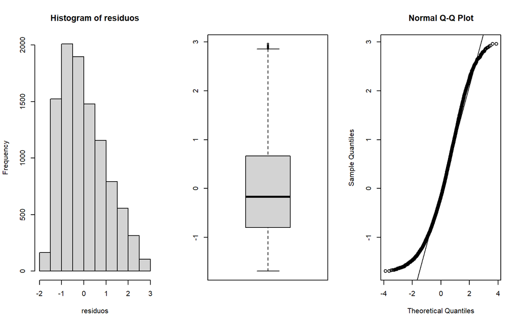

```r
residuos <- rstandard(modelo) #Residuos estándares del modelo ajustado (Completo)
par(mfrow=c(1,3)) #Divide la ventana en una fila y tres columnas
hist(residuos) #Histograma de los resiudos estandarizados
boxplot(residuos) #Diagrama de cajas de los residuos estandarizados

qqnorm(residuos) #Gráfico de cuantiles de los residuos estandarizados

qqline(residuos)
```

```r
par(mfrow=c(1,1)) #Devuelve la pantalla a su estado original
```

### Varianza constante:

La varianza de los errores es constante

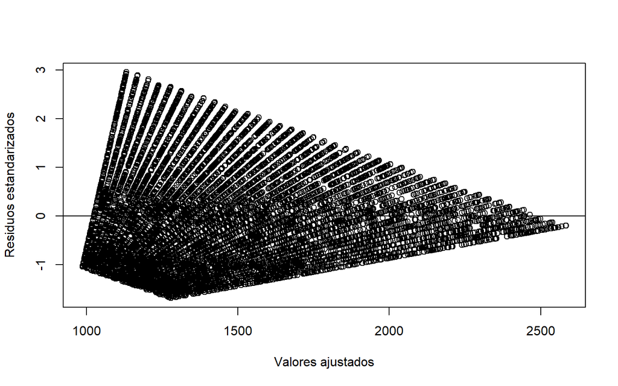

```r
plot(fitted.values(modelo), rstandard(modelo), xlab= "Valores ajustados", ylab= "Residuos estandarizados") # gráfico 2D de los valores ajustados vs. los residuos estandarizados
abline(h=0) # dibuja la recta en cero
```

Valores atípicos: La independencia de los errores

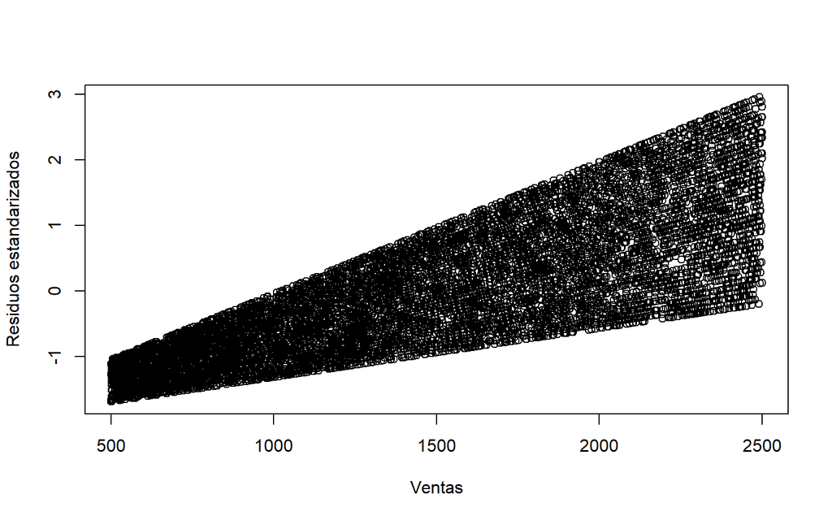

```r
plot(india$Venta,rstandard(modelo),xlab="Ventas",ylab="Residuos estandarizados")
```

### Visualización de la regresión

[figure not shown]

```r
plot(india$Venta, india$Ganacia, xlab = "Ganancias",ylab= "ventas")
abline(modelo)
```

### Análisis de regresión logística en R

Para realizar este analisis necesitamos estos requisitos:

Variable dependiente: no métrica (dicotómica)

Variables independientes: métricas y no métricas

Según la data que se tiene no contamos con variable dicotomicas

# Series Temporales

```r
ventas <- indiaStore$Venta
```

```r
ventas.ts = ts(ventas, start = c(2015,1),end = c(2018,12),frequency = 12)
print(ventas.ts)
```

```
##       Jan  Feb  Mar  Apr  May  Jun  Jul  Aug  Sep  Oct  Nov  Dec
## 2015 1254  749 2360  896 2355 2305  826 1847  791 1795 1903  701
## 2016 1659 1277  831 1440 1678 1617 1757  692  522  948  707  969
## 2017 1100 2022  541  979 1988  989 1845 1400 2163 1689  809 1265
## 2018  934 1354 1751 2045  660 1868 1017 2311 1663 1420 1415 1488
```

```r
start(ventas.ts);end(ventas.ts)
```

```
## [1] 2015    1
```

```
## [1] 2018   12
```

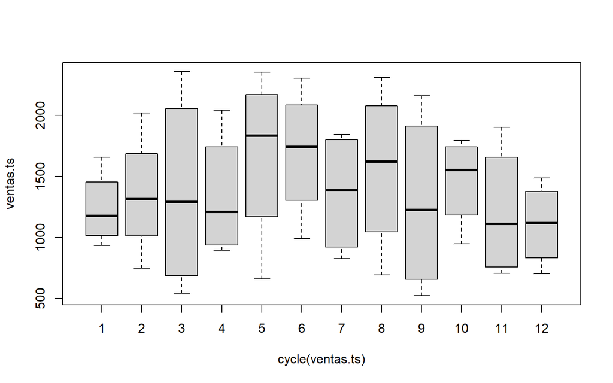

```r
boxplot(ventas.ts ~ cycle(ventas.ts))
```

```r
cycle(ventas.ts)
```

```
##      Jan Feb Mar Apr May Jun Jul Aug Sep Oct Nov Dec
## 2015   1   2   3   4   5   6   7   8   9  10  11  12
## 2016   1   2   3   4   5   6   7   8   9  10  11  12
## 2017   1   2   3   4   5   6   7   8   9  10  11  12
## 2018   1   2   3   4   5   6   7   8   9  10  11  12
```

```r
class(ventas.ts)
```

```
## [1] "ts"
```

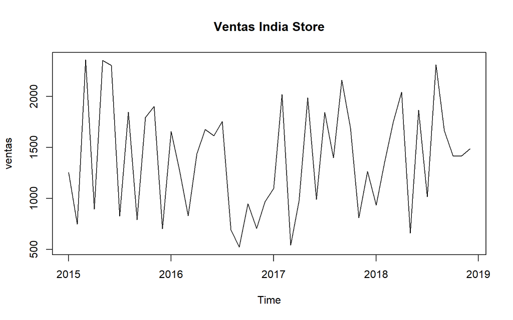

```r
plot(ventas.ts, ylab= "ventas", main= "Ventas India Store")
```

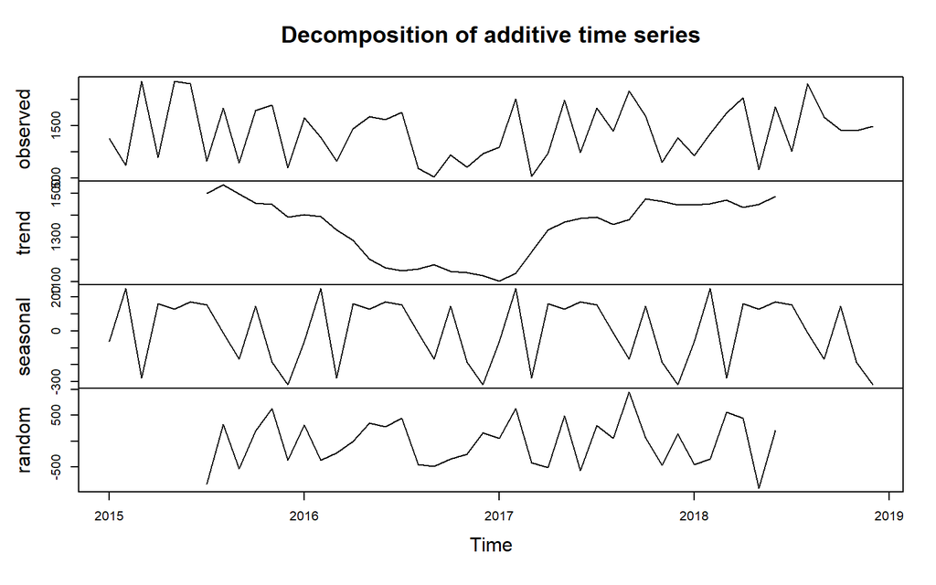

```r
modeloAditivo=decompose(ventas.ts)
plot(modeloAditivo)
```

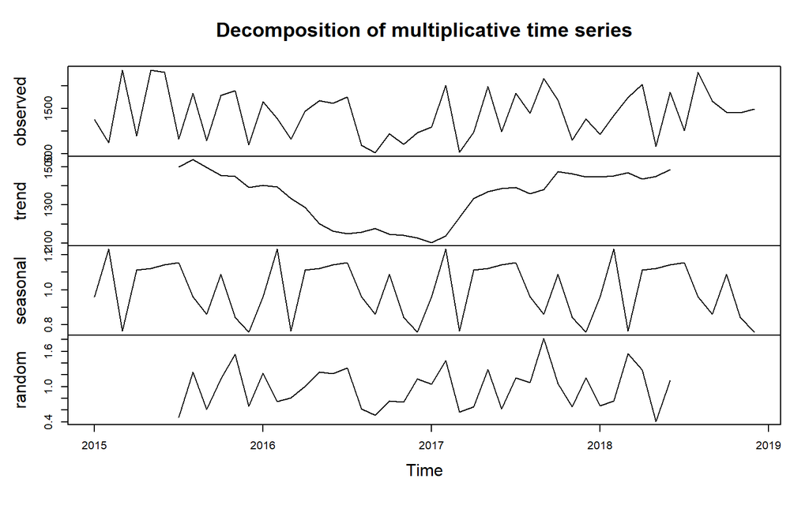

```r
modelomulti = decompose(ventas.ts, type = "mult")
plot(modelomulti)
```

#Estimacion de la tendencia

```r
Tendencia = modelomulti$trend
print(Tendencia)
```

```
##           Jan      Feb      Mar      Apr      May      Jun      Jul      Aug
## 2015       NA       NA       NA       NA       NA       NA 1498.708 1537.583
## 2016 1402.542 1393.208 1333.875 1287.375 1202.250 1163.583 1151.458 1159.208
## 2017 1104.833 1138.000 1235.875 1335.125 1370.250 1386.833 1392.250 1357.500
## 2018 1447.417 1450.875 1468.000 1435.958 1450.000 1484.542       NA       NA
##           Sep      Oct      Nov      Dec
## 2015 1495.875 1454.833 1449.292 1392.417
## 2016 1178.167 1146.875 1140.583 1127.333
## 2017 1380.083 1474.917 1464.000 1445.292
## 2018       NA       NA       NA       NA
```

Estimacion de la estacionalidad

```r
Estacionalidad = modelomulti$seasonal
print(Estacionalidad)
```

```
##            Jan       Feb       Mar       Apr       May       Jun       Jul
## 2015 0.9587555 1.2313497 0.7651405 1.1122881 1.1210355 1.1412002 1.1551605
## 2016 0.9587555 1.2313497 0.7651405 1.1122881 1.1210355 1.1412002 1.1551605
## 2017 0.9587555 1.2313497 0.7651405 1.1122881 1.1210355 1.1412002 1.1551605
## 2018 0.9587555 1.2313497 0.7651405 1.1122881 1.1210355 1.1412002 1.1551605
##            Aug       Sep       Oct       Nov       Dec
## 2015 0.9607034 0.8621182 1.0883871 0.8439071 0.7599542
## 2016 0.9607034 0.8621182 1.0883871 0.8439071 0.7599542
## 2017 0.9607034 0.8621182 1.0883871 0.8439071 0.7599542
## 2018 0.9607034 0.8621182 1.0883871 0.8439071 0.7599542
```

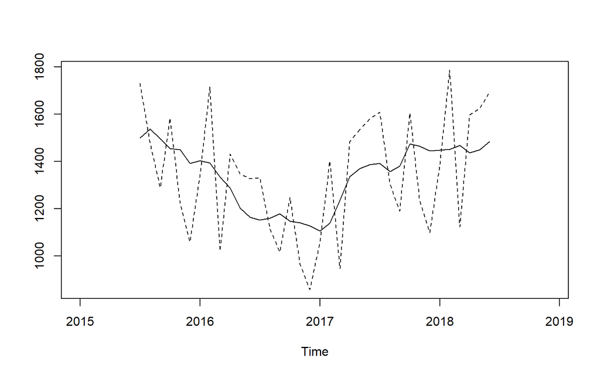

```r
ts.plot(cbind(Tendencia, Tendencia*Estacionalidad), lty= 1:2)
```

```r
library(ggplot2)
library(ggfortify)
library(forecast)
```

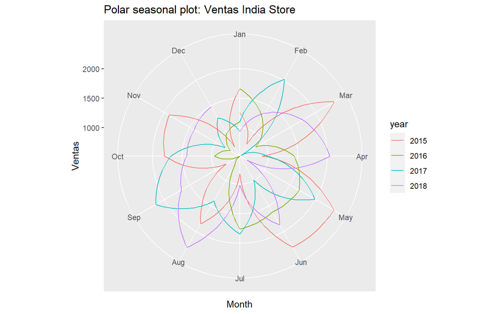

```r
ggseasonplot(ventas.ts, polar = TRUE) +
  ylab("Ventas") + ggtitle("Polar seasonal plot: Ventas India Store")
```

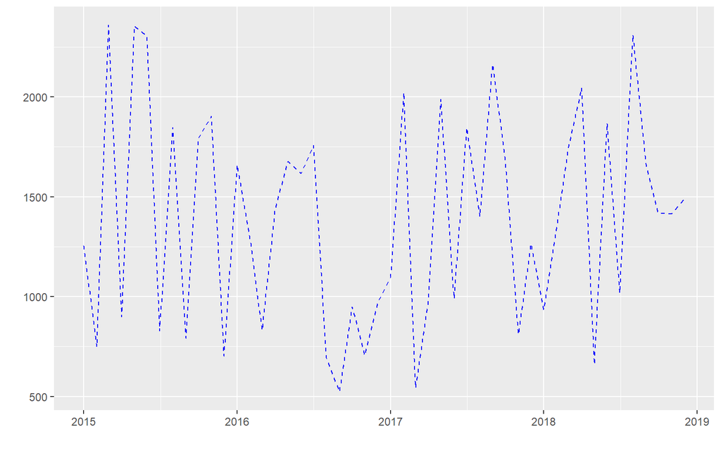

```r
autoplot(ventas.ts, ts.colour = "blue", ts.linetype = "dashed")
```

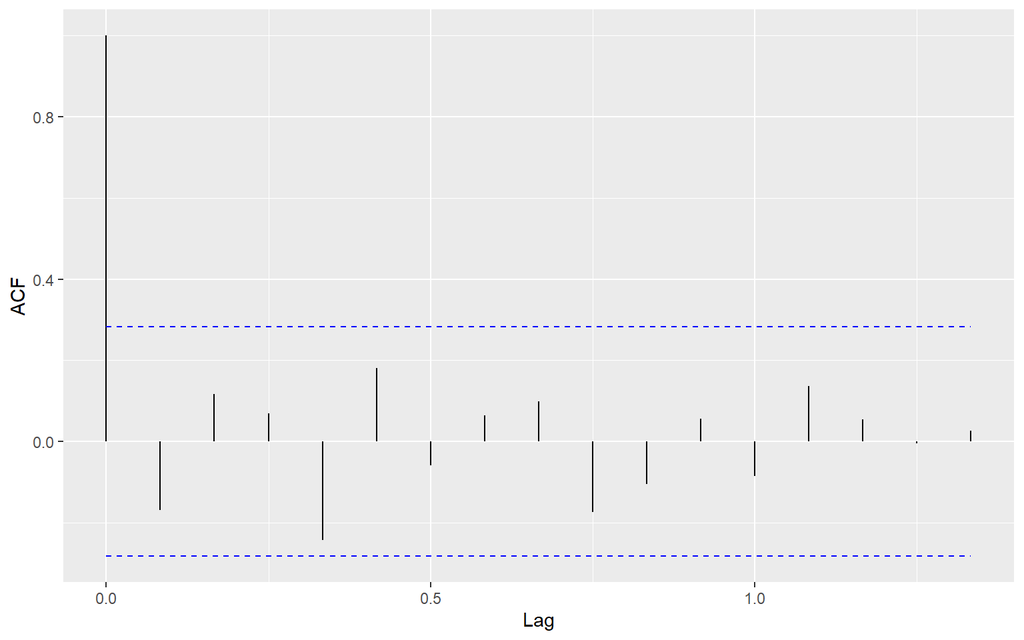

```r
autoplot(acf(ventas.ts, plot = FALSE))
```

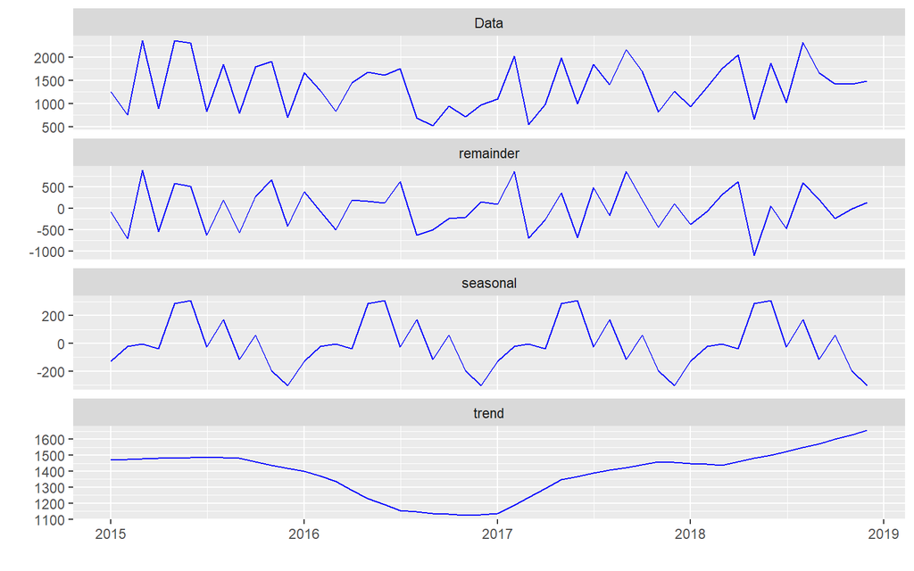

```r
autoplot(stl(ventas.ts, s.window = "periodic"), ts.colour = "blue")
```

Cambiando a estacionario #modelo ARIMA -Diferencias

```r
ndiffs(ventas.ts)
```

```
## [1] 0
```

```r
nsdiffs(ventas.ts)
```

```
## [1] 0
```

Validamos con Diff la estacionariedad

```r
diff.ventas1=diff(ventas.ts)
adf.test(diff.ventas1)
```

```
##
##  Augmented Dickey-Fuller Test
##
## data:  diff.ventas1
## Dickey-Fuller = -5.9238, Lag order = 3, p-value = 0.01
## alternative hypothesis: stationary
```

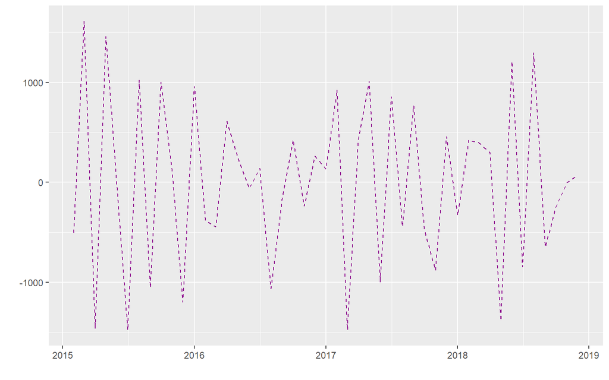

```r
diff.ventas<-autoplot(diff(ventas.ts), ts.linetype = "dashed", ts.colour = "darkmagenta")
diff.ventas
```

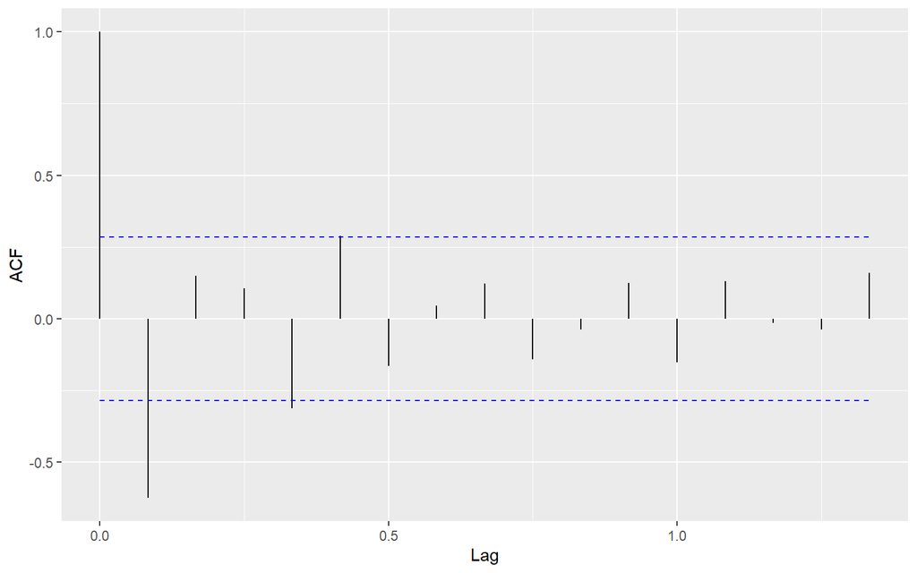

```r
autoplot(acf(diff(ventas.ts), plot = FALSE))
```

```r
#monthplot(diff(ventas.ts), col = "midnightblue")
```

Conversion con Logaritmo

```r
serielog=log(ventas.ts)
serielog
```

```
##           Jan      Feb      Mar      Apr      May      Jun      Jul      Aug
## 2015 7.134094 6.618739 7.766417 6.797940 7.764296 7.742836 6.716595 7.521318
## 2016 7.413970 7.152269 6.722630 7.272398 7.425358 7.388328 7.471363 6.539586
## 2017 7.003065 7.611842 6.293419 6.886532 7.594884 6.896694 7.520235 7.244228
## 2018 6.839476 7.210818 7.467942 7.623153 6.492240 7.532624 6.924612 7.745436
##           Sep      Oct      Nov      Dec
## 2015 6.673298 7.492760 7.551187 6.552508
## 2016 6.257668 6.854355 6.561031 6.876265
## 2017 7.679251 7.431892 6.695799 7.142827
## 2018 7.416378 7.258412 7.254885 7.305188
```

```r
library(aTSA)
```

```r
#plot(serielog)
#adf.test(serielog,alternative = "stationary")
```

Luego Hacemos el modelo Arima con la data de DIFF Primero Ploteamos

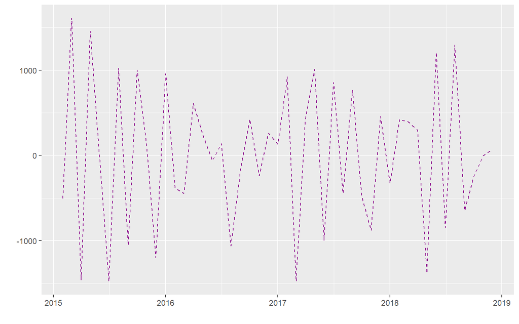

```r
plot(diff.ventas, type="o",lty="dashed",col="blue",main="Serie de Tiempo")
```

#Calculamos la funcion de autocorrelacion y autocorrelacion parcial, para saber cuantas medias moviles tenemos

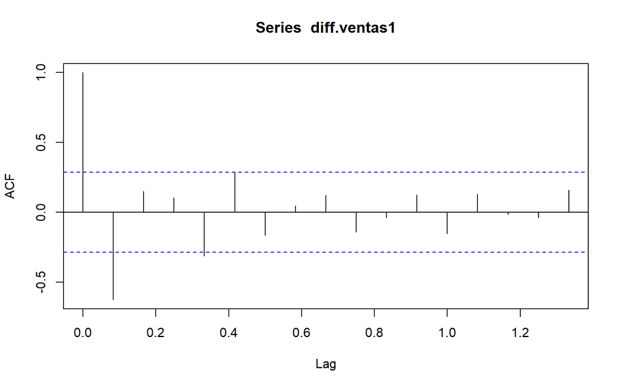

```r
#Autocorrelacion / Numero de medias moviles
acf(diff.ventas1)
```

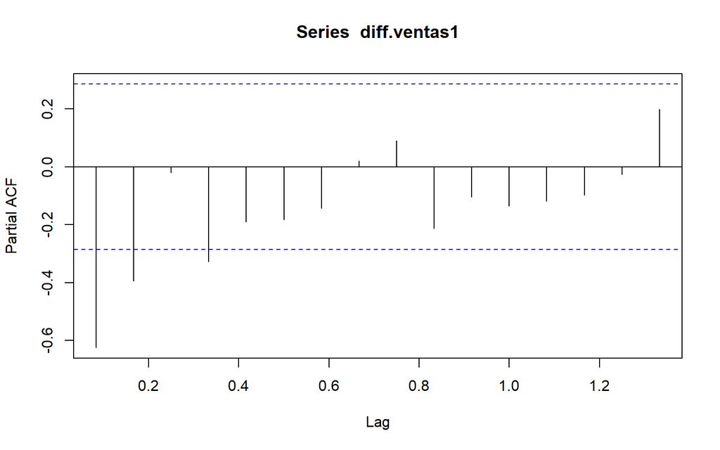

```r
#Autocorrelacion Parcial / numero de autoregresivos
pacf(diff.ventas1)
```

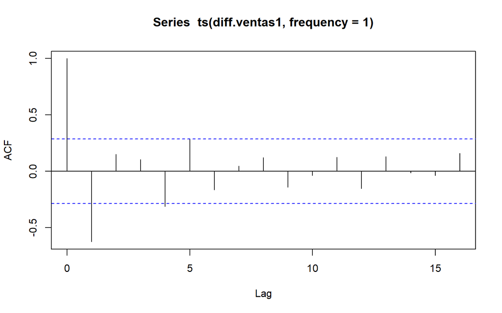

```r
# Las frecuencias de la serie tienen que ser igual a los resagos para ello se usa la siguiente funcion.
acf(ts(diff.ventas1, frequency = 1))
```

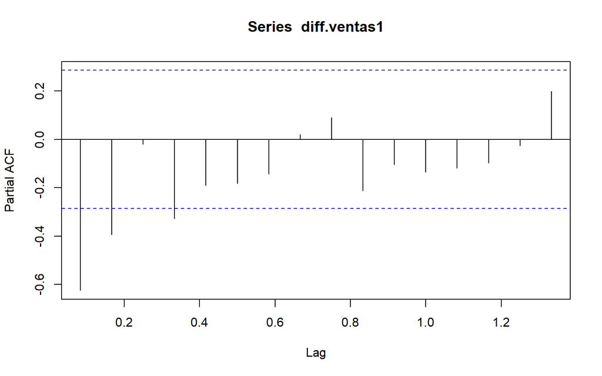

```r
pacf(diff.ventas1, frequency=1)
```